```python
#NumPy is a Python Library used to perform wide variety of Mathematical Operations on Arrays.
import numpy as np
#Pandas is a Python Library used to analyze big data and make Conclusions based on Stastical Theories.
import pandas as pd
#matplotlib.pyplot contains functions that make matplotlib work like MATLAB and
#each pyplot fuction makes some changes in the figure.
import matplotlib.pyplot as plt
#plotly.express contains functions that can create Entire Figures.
import plotly.express as px
import plotly.graph_objects as go
from plotly.offline import iplot, plot
from plotly.subplots import make_subplots
import seaborn as sns
```

# Importing the Dataset.

```python
#Loading the Dataset.
Data=pd.read_csv("C:\\Users\\Admin\\Desktop\\Madhu\\Anaconda-Jupyter\\Amazon Prime Jupyter Project\\Raw Data.csv")
```

```python
#To get First 5 Rows of Dataset.
Data.head()
```

|  | S.no. | Name of the show | Year of release | No of seasons available | Language | Genre | IMDb rating | Age of viewers |
| --- | --- | --- | --- | --- | --- | --- | --- | --- |
| 0 | 1 | Pataal Lok | 2020 | 1 | Hindi | Drama | 7.5 | 18+ |
| 1 | 2 | Upload | 2020 | 1 | English | Sci-fi comedy | 8.1 | 16+ |
| 2 | 3 | The Marvelous Mrs. Maisel | 2017 | 3 | English | Drama, Comedy | 8.7 | 16+ |
| 3 | 4 | Four More Shots Please | 2019 | 2 | Hindi | Drama, Comedy | 5.3 | 18+ |
| 4 | 5 | Fleabag | 2016 | 2 | English | Comedy | 8.7 | 18+ |

```python
#To get Last 5 Rows of Dataset.
Data.tail()
```

|  | S.no. | Name of the show | Year of release | No of seasons available | Language | Genre | IMDb rating | Age of viewers |
| --- | --- | --- | --- | --- | --- | --- | --- | --- |
| 498 | 499 | The Bellflower Bunnies | 2002 | 1 | English | Kids | NaN | All |
| 499 | 500 | Truck Games | 2020 | 1 | English | Kids | NaN | All |
| 500 | 501 | AnimaCars- Truck and Animal's Adventures | 2019 | 1 | English | Kids | NaN | All |
| 501 | 502 | Superzoo | 2020 | 1 | English | Kids | NaN | All |
| 502 | 503 | Dubby Dubs | 2017 | 2 | English | Kids | NaN | 7+ |

```python
#To get Random 5 Sample Rows from the Dataset
Data.sample(5)
```

|  | S.no. | Name of the show | Year of release | No of seasons available | Language | Genre | IMDb rating | Age of viewers |
| --- | --- | --- | --- | --- | --- | --- | --- | --- |
| 378 | 379 | WassUp With You | 2018 | 2 | Marathi | Comedy | NaN | 13+ |
| 407 | 408 | Kung Fu Panda: The Paws of Destiny | 2018 | 2 | English | Kids | 7.6 | All |
| 485 | 486 | Groovy the Martian | 2020 | 1 | English | Kids | NaN | All |
| 281 | 282 | Seinfeld | 1990 | 9 | English | Comedy | 8.8 | 13+ |
| 26 | 27 | Jestination Unknown | 2019 | 1 | Hindi | Comedy, Arts, Entertainment, Culture | 6.2 | 16+ |

# Checking the Dataset.

```python
#To get Shape and Size of the Data.
Data.info()
```

```
<class 'pandas.core.frame.DataFrame'>
RangeIndex: 503 entries, 0 to 502
Data columns (total 8 columns):
 #   Column                   Non-Null Count  Dtype
---  ------                   --------------  -----
 0   S.no.                    503 non-null    int64
 1   Name of the show         503 non-null    object
 2   Year of release          503 non-null    int64
 3   No of seasons available  503 non-null    int64
 4   Language                 503 non-null    object
 5   Genre                    503 non-null    object
 6   IMDb rating              220 non-null    float64
 7   Age of viewers           503 non-null    object
dtypes: float64(1), int64(3), object(4)
memory usage: 31.6+ KB
```

```python
#To get the Shape of the Dataset.
Data.shape
```

```
(503, 8)
```

```python
#To get all the Information regarding the Dataset.
Data.describe()
```

|  | S.no. | Year of release | No of seasons available | IMDb rating |
| --- | --- | --- | --- | --- |
| count | 503.000000 | 503.000000 | 503.000000 | 220.000000 |
| mean | 252.000000 | 2011.914513 | 2.514911 | 7.252727 |
| std | 145.347859 | 11.945704 | 2.400049 | 1.014840 |
| min | 1.000000 | 1926.000000 | 1.000000 | 3.700000 |
| 25% | 126.500000 | 2011.000000 | 1.000000 | 6.700000 |
| 50% | 252.000000 | 2016.000000 | 2.000000 | 7.400000 |
| 75% | 377.500000 | 2018.000000 | 3.000000 | 8.000000 |
| max | 503.000000 | 2020.000000 | 20.000000 | 9.000000 |

# Cleaning the Dataset.

```python
#To check the Null Values in the Dataset.
Data.isnull().sum()
```

```
S.no.                        0
Name of the show             0
Year of release              0
No of seasons available      0
Language                     0
Genre                        0
IMDb rating                283
Age of viewers               0
dtype: int64
```

```python
#Replace the null values of IMDB Ratings using Median.
Median=Data['IMDb rating'].median()
Data['IMDb rating'].fillna(Median,inplace=True)
```

```python
Data.isnull().sum()
```

```
S.no.                      0
Name of the show           0
Year of release            0
No of seasons available    0
Language                   0
Genre                      0
IMDb rating                0
Age of viewers             0
dtype: int64
```

```python
#To Drop the S.no. Column.
Data.drop(['S.no.'],axis=1,inplace=True)
Data
```

|  | Name of the show | Year of release | No of seasons available | Language | Genre | IMDb rating | Age of viewers |
| --- | --- | --- | --- | --- | --- | --- | --- |
| 0 | Pataal Lok | 2020 | 1 | Hindi | Drama | 7.5 | 18+ |
| 1 | Upload | 2020 | 1 | English | Sci-fi comedy | 8.1 | 16+ |
| 2 | The Marvelous Mrs. Maisel | 2017 | 3 | English | Drama, Comedy | 8.7 | 16+ |
| 3 | Four More Shots Please | 2019 | 2 | Hindi | Drama, Comedy | 5.3 | 18+ |
| 4 | Fleabag | 2016 | 2 | English | Comedy | 8.7 | 18+ |
| ... | ... | ... | ... | ... | ... | ... | ... |
| 498 | The Bellflower Bunnies | 2002 | 1 | English | Kids | 7.4 | All |
| 499 | Truck Games | 2020 | 1 | English | Kids | 7.4 | All |
| 500 | AnimaCars- Truck and Animal's Adventures | 2019 | 1 | English | Kids | 7.4 | All |
| 501 | Superzoo | 2020 | 1 | English | Kids | 7.4 | All |
| 502 | Dubby Dubs | 2017 | 2 | English | Kids | 7.4 | 7+ |

503 rows × 7 columns

# Analysing and Visualizing the Dataset.

1)(i) To get the List of Number of Shows per Year.

```python
Year=Data['Year of release'].value_counts()
Year
```

```
Year of release
2018    78
2019    60
2017    58
2016    49
2020    38
2015    38
2014    26
2013    14
2012    14
2010    12
2011    12
2007    10
2005     8
2009     7
```

[output cut: 33 more lines]

1)(ii) To Plot the Graph.

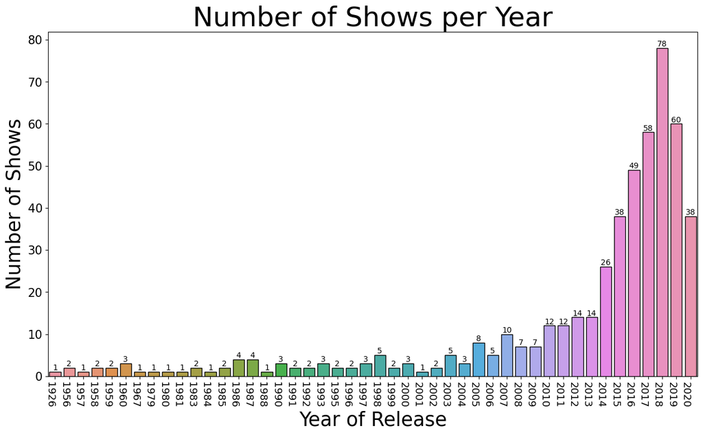

```python
plt.figure(figsize=(15,8))
plt.title('Number of Shows per Year',fontsize=35)
plt.xticks(rotation=270,ha='right',fontsize=13)
plt.yticks(fontsize=15)
plt.xlabel('',fontsize=25)
plt.ylabel('',fontsize=25)
Graph=sns.countplot(x='Year of release',data=Data,edgecolor='black')
Graph.set(ylabel='Number of Shows',xlabel='Year of Release')
Graph.bar_label(Graph.containers[0])
plt.show()
```

2)(i) To get the List of Number of Seasons.

```python
Seasons=Data['No of seasons available'].value_counts()
Seasons
```

```
No of seasons available
1     244
2      99
3      46
4      39
5      30
7      13
6      13
8       5
9       4
10      3
15      2
12      2
13      1
17      1
20      1
Name: count, dtype: int64
```

2)(ii) To Plot the Graph

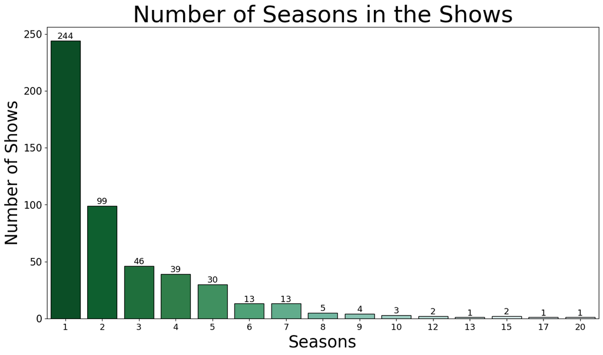

```python
plt.figure(figsize=(15,8))
plt.title('Number of Seasons in the Shows',fontsize=35)
plt.xticks(fontsize=13)
plt.yticks(fontsize=15)
plt.xlabel('',fontsize=25)
plt.ylabel('',fontsize=25)
Graph=sns.countplot(x='No of seasons available',data=Data,palette='BuGn_r',edgecolor='black')
Graph.set(ylabel='Number of Shows',xlabel='Seasons')
Graph.bar_label(Graph.containers[0],fontsize=13)
plt.show()
```

3)(i) To get the List of Number of Languages.

```python
Languages=Data['Language'].value_counts()
Languages
```

```
Language
English       422
Hindi          39
Japanese       13
Italiano        8
Spanish         6
Deutsch         3
Nederlands      2
French          2
Serbian         2
Marathi         2
Telugu          1
Hebrew          1
Russian         1
Suomi           1
Name: count, dtype: int64
```

3)(ii) To Plot the Graph.

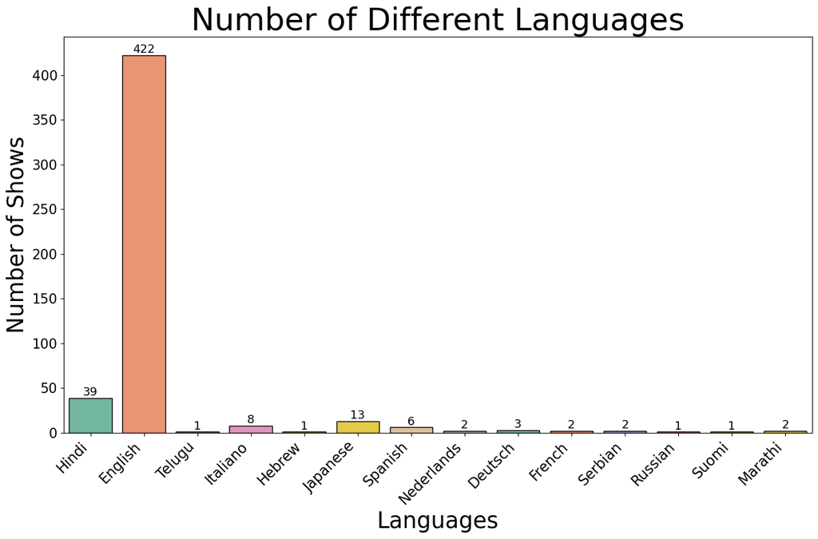

```python
plt.figure(figsize=(15,8))
plt.title('Number of Different Languages',fontsize=35)
plt.xticks(rotation=45,ha='right',fontsize=16)
plt.yticks(fontsize=15)
plt.xlabel('',fontsize=25)
plt.ylabel('',fontsize=25)
Graph=sns.countplot(x='Language',data=Data,palette='Set2',edgecolor='black')
Graph.set(ylabel='Number of Shows',xlabel='Languages')
Graph.bar_label(Graph.containers[0],fontsize=13)
plt.show()
```

4)(i) To get the List of Number of Shows in each Genres.

```python
Genres=Data['Genre'].value_counts()
Genres
```

```
Genre
Kids                                          127
Drama                                         125
Comedy                                         98
Action                                         26
Drama, Comedy                                  15
Drama, Suspense                                12
Arts, Entertainment, Culture                   12
Drama, Action                                  11
Crime                                           8
Drama, Sci-fi                                   7
Documentary                                     5
Drama, Romance                                  4
Sci-fi                                          4
Drama, Action, Suspense                         3
Drama, Horror, Suspense                         2
Sports, Drama                                   2
Animation                                       2
Kids, Animation                                 2
Adventure                                       2
Drama, Fantasy                                  2
Drama, Horror                                   2
Drama, Documentary                              2
Drama, Suspense, Action                         2
Drama, Comeddy                                  1
Drama, LGBTQ, Arts, Entertainment, Culture      1
Horror                                          1
Drama, Comedy, LGBTQ                            1
Animation, Drama                                1
Drama, Sports                                   1
Drama, Comedy, Action                           1
Sci-fi, Action, Suspense                        1
Drama, Romance, Comedy                          1
Sports                                          1
Romance                                         1
Drama, Sci-fi, Suspense, Action                 1
Drama, Action, Sci-fi                           1
Action, Comedy                                  1
Drama, Action, Adventure                        1
Sci-fi, Drama, Suspense                         1
Fantasy                                         1
Fantasy, Comedy                                 1
Drama, Suspense, Adventure                      1
Sci-fi comedy                                   1
Comedy, Drama                                   1
Drama, Suspense, Fantasy                        1
Drama, Suspense, Horror                         1
Drama, Horror, Romance, Suspense                1
Sci-fi                                          1
Comedy, Arts, Entertainment, Culture            1
Comedy, Action                                  1
Drama, Horror, Fantasy                          1
Name: count, dtype: int64
```

4)(ii) To Plot the Graph.

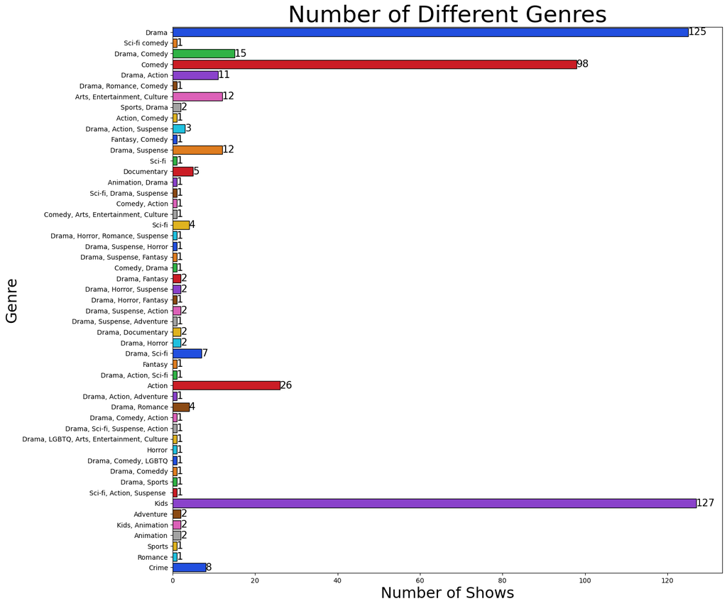

```python
plt.figure(figsize=(15,15))
plt.title('Number of Different Genres',fontsize=35)
plt.xlabel('',fontsize=23)
plt.ylabel('',fontsize=23)
Graph=sns.countplot(y='Genre',data=Data,palette='bright',edgecolor='black')
Graph.set(xlabel='Number of Shows',ylabel='Genre')
Graph.bar_label(Graph.containers[0],fontsize=15)
plt.show()
```

4)(iii) To get the List of Top 10 Genres with Highest no of Shows.

```python
Genres.head(10)
```

```
Genre
Kids                            127
Drama                           125
Comedy                           98
Action                           26
Drama, Comedy                    15
Drama, Suspense                  12
Arts, Entertainment, Culture     12
Drama, Action                    11
Crime                             8
Drama, Sci-fi                     7
Name: count, dtype: int64
```

4)(iv) To Plot the Bar Graph.

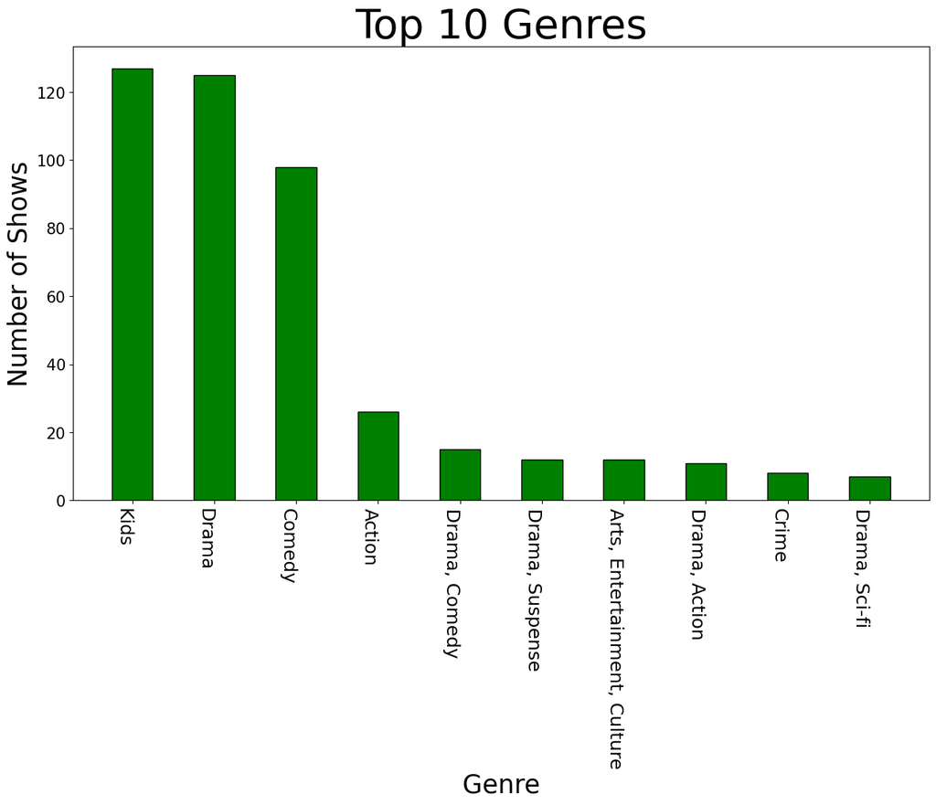

```python
Genre_Names=Genres[:10].index
Counts=Genres[:10]
plt.figure(figsize=(15,8))
plt.bar(Genre_Names,Counts,width=0.5,edgecolor='black',color='green')
plt.xticks(rotation=270,ha='right',fontsize=18)
plt.yticks(fontsize=15)
plt.xlabel('Genre',fontsize=25)
plt.ylabel('Number of Shows',fontsize=25)
plt.title('Top 10 Genres',color='black',fontsize=40)
plt.show()
```

4)(v) To find the List of Top 10 Popular Genres.

```python
Top_10_Genre=Data.sort_values('IMDb rating',ascending=False)[['Genre','IMDb rating']][:10]
Top_10_Genre
```

|  | Genre | IMDb rating |
| --- | --- | --- |
| 20 | Documentary | 9.0 |
| 281 | Comedy | 8.8 |
| 49 | Drama | 8.7 |
| 2 | Drama, Comedy | 8.7 |
| 37 | Drama, Comedy | 8.7 |
| 4 | Comedy | 8.7 |
| 340 | Sports | 8.7 |
| 51 | Drama | 8.7 |
| 12 | Action, Comedy | 8.7 |
| 40 | Drama | 8.6 |

4)(vi) To plot the Bar Graph.

[figure not shown]

```python
plt.figure(figsize=(7,4))
plt.title('Top 10 Popular Genres',fontsize=25)
plt.xlabel('',fontsize=18)
plt.ylabel('',fontsize=18)
plt.xticks(rotation=270,ha='right',fontsize=12)
plt.yticks(fontsize=14)
Graph=sns.barplot(data=Top_10_Genre,y='IMDb rating',x='Genre',palette='autumn',
                  edgecolor='black',errorbar=None)
Graph.set(xlabel='Genre',ylabel='IMDB Ratings')
Graph.bar_label(Graph.containers[0],fontsize=10)
plt.show()
```

4)(vii) To find the List of Top 10 TV shows in the Genre=Drama.

```python
Drama=Data[Data['Genre']=='Drama'].sort_values('IMDb rating',ascending=False)
Drama.head(10)
```

|  | Name of the show | Year of release | No of seasons available | Language | Genre | IMDb rating | Age of viewers |
| --- | --- | --- | --- | --- | --- | --- | --- |
| 51 | This is Us | 2017 | 3 | English | Drama | 8.7 | 16+ |
| 49 | Downtown Abbey | 2010 | 6 | English | Drama | 8.7 | 7+ |
| 105 | Mad Men | 2007 | 7 | English | Drama | 8.6 | 16+ |
| 40 | Dexter | 2006 | 8 | English | Drama | 8.6 | 18+ |
| 85 | The Handmaid's Tale | 2017 | 3 | English | Drama | 8.5 | 18+ |
| 7 | Mirzapur | 2018 | 1 | Hindi | Drama | 8.5 | 18+ |
| 28 | Suits | 2011 | 8 | English | Drama | 8.5 | 16+ |
| 76 | Bosch | 2015 | 6 | English | Drama | 8.4 | 18+ |
| 142 | Ray Donovan | 2013 | 6 | English | Drama | 8.3 | All |
| 154 | Life | 2007 | 2 | English | Drama | 8.3 | All |

4)(viii) To find the List of Top 10 TV shows in the Genre=Comedy.

```python
Comedy=Data[Data['Genre']=='Comedy'].sort_values('IMDb rating',ascending=False)
Comedy.head(10)
```

|  | Name of the show | Year of release | No of seasons available | Language | Genre | IMDb rating | Age of viewers |
| --- | --- | --- | --- | --- | --- | --- | --- |
| 281 | Seinfeld | 1990 | 9 | English | Comedy | 8.8 | 13+ |
| 4 | Fleabag | 2016 | 2 | English | Comedy | 8.7 | 18+ |
| 261 | Mr. Bean | 1995 | 1 | English | Comedy | 8.5 | 16+ |
| 293 | Californication | 2007 | 7 | English | Comedy | 8.3 | 18+ |
| 299 | Best of AIB | 2014 | 1 | Hindi | Comedy | 8.2 | 16+ |
| 330 | EIC vs The World | 2017 | 1 | English | Comedy | 8.0 | 16+ |
| 312 | Trial and Error | 2017 | 2 | English | Comedy | 8.0 | 13+ |
| 374 | Hitoshi Matsumoto Presents Documental | 2018 | 3 | Japanese | Comedy | 8.0 | 18+ |
| 315 | Red Oaks | 2015 | 3 | English | Comedy | 7.9 | 18+ |
| 347 | People of Earth | 2016 | 2 | English | Comedy | 7.7 | All |

4)(ix) To find the List of Top 10 TV shows in the Genre=Kids.

```python
Kids=Data[Data['Genre']=='Kids'].sort_values('IMDb rating',ascending=False)
Kids.head(10)
```

|  | Name of the show | Year of release | No of seasons available | Language | Genre | IMDb rating | Age of viewers |
| --- | --- | --- | --- | --- | --- | --- | --- |
| 436 | Tumble Leaf | 2014 | 6 | English | Kids | 8.6 | All |
| 296 | Munki and Trunk | 2016 | 1 | English | Kids | 8.4 | All |
| 452 | Jessy and Nessy | 2020 | 1 | English | Kids | 8.3 | All |
| 411 | Gortimer Gibbon's Life on Normal Street | 2015 | 3 | English | Kids | 8.2 | All |
| 405 | Just Add Magic | 2016 | 5 | English | Kids | 8.2 | All |
| 437 | Wolverine and the X-men | 2016 | 1 | English | Kids | 8.0 | 7+ |
| 421 | Dexter's Laboratory | 1997 | 5 | English | Kids | 7.9 | All |
| 423 | Transformers Prime | 2012 | 3 | English | Kids | 7.8 | 7+ |
| 226 | Lost in Oz | 2017 | 2 | English | Kids | 7.7 | 7+ |
| 450 | Niko and The Sword of Light | 2017 | 3 | English | Kids | 7.7 | All |

5)(i) To get the List of Age of Viewers.

```python
Age_of_Viewers=Data['Age of viewers'].value_counts()
Age_of_Viewers
```

```
Age of viewers
16+    154
All    144
18+     79
13+     76
7+      50
Name: count, dtype: int64
```

5)(ii) To Plot the Pie Chart.

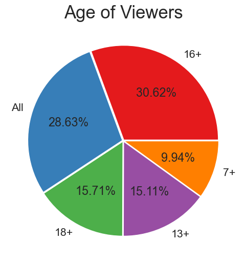

```python
sns.set(font_scale=1.4)
plt.figure(figsize=(6,6))
plt.title('Age of Viewers',fontsize=25)
plt.pie(Age_of_Viewers,labels=Age_of_Viewers.index,autopct='%.2f%%',colors=sns.color_palette('Set1'),
       explode=[0.01, 0.01, 0.01, 0.01, 0.01])
plt.show()
```

5)(iii) To Plot the Bar Graph.

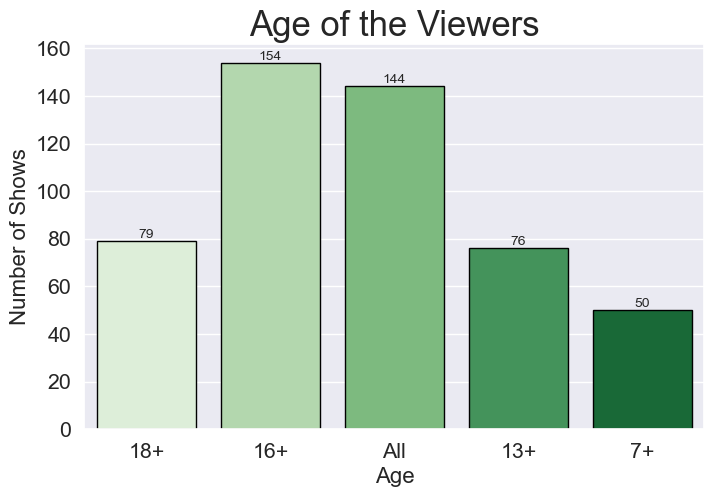

```python
plt.figure(figsize=(8,5))
plt.title('Age of the Viewers',fontsize=25)
plt.xlabel('',fontsize=16)
plt.ylabel('',fontsize=16)
Graph=sns.countplot(x='Age of viewers',data=Data,palette='Greens',edgecolor='black')
Graph.set(ylabel='Number of Shows',xlabel='Age')
Graph.bar_label(Graph.containers[0],fontsize=10)
plt.show()
```

6)(i) To Get the List of Top 10 Highest Rated Shows.

```python
Highest=Data.sort_values(by='IMDb rating',ascending=False).head(10)
Highest
```

|  | Name of the show | Year of release | No of seasons available | Language | Genre | IMDb rating | Age of viewers |
| --- | --- | --- | --- | --- | --- | --- | --- |
| 20 | The Test: A New Era for Australia's Team | 2020 | 1 | English | Documentary | 9.0 | 16+ |
| 281 | Seinfeld | 1990 | 9 | English | Comedy | 8.8 | 13+ |
| 49 | Downtown Abbey | 2010 | 6 | English | Drama | 8.7 | 7+ |
| 2 | The Marvelous Mrs. Maisel | 2017 | 3 | English | Drama, Comedy | 8.7 | 16+ |
| 37 | Hostel Daze | 2019 | 1 | Hindi | Drama, Comedy | 8.7 | 16+ |
| 4 | Fleabag | 2016 | 2 | English | Comedy | 8.7 | 18+ |
| 340 | The Grand Tour | 2017 | 4 | English | Sports | 8.7 | 16+ |
| 51 | This is Us | 2017 | 3 | English | Drama | 8.7 | 16+ |
| 12 | The Boys | 2019 | 1 | English | Action, Comedy | 8.7 | 18+ |
| 40 | Dexter | 2006 | 8 | English | Drama | 8.6 | 18+ |

6)(ii) To Plot the Bar Graph.

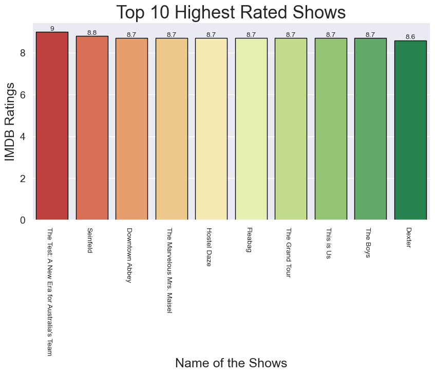

```python
plt.figure(figsize=(10,5))
plt.title('Top 10 Highest Rated Shows',fontsize=25)
plt.xlabel('',fontsize=18)
plt.ylabel('',fontsize=18)
plt.xticks(rotation=270,ha='right',fontsize=10)
plt.yticks(fontsize=14)
Graph=sns.barplot(data=Highest,y='IMDb rating',x='Name of the show',palette='RdYlGn',
                  edgecolor='black')
Graph.set(xlabel='Name of the Shows',ylabel='IMDB Ratings')
Graph.bar_label(Graph.containers[0],fontsize=10)
plt.show()
```

7)(i) To Get the List of Top 10 Lowest Rated Shows.

```python
Lowest=Data.sort_values(by='IMDb rating',ascending=True).head(10)
Lowest
```

|  | Name of the show | Year of release | No of seasons available | Language | Genre | IMDb rating | Age of viewers |
| --- | --- | --- | --- | --- | --- | --- | --- |
| 367 | Ilana Glazer: The Planet is Burning | 2020 | 1 | English | Comedy | 3.7 | 18+ |
| 162 | Tokyo Alice | 2019 | 1 | Japanese | Drama | 4.0 | 13+ |
| 243 | Skulls and Roses | 2019 | 1 | Hindi | Action | 4.3 | 18+ |
| 428 | L.O.L Surprise | 2019 | 1 | English | Kids | 4.3 | All |
| 413 | Wishenpoof | 2015 | 4 | English | Kids | 4.4 | All |
| 375 | Businessmen VS Aliens | 2018 | 1 | Japanese | Comedy | 4.5 | 13+ |
| 430 | Alvin and the Chipmunks | 2017 | 4 | English | Kids | 4.5 | 7+ |
| 317 | Alice Wettlund: My Mama is a Human and So Am I | 2019 | 1 | English | Comedy | 4.7 | 16+ |
| 466 | Strawberry Shortcake | 2003 | 1 | English | Kids | 4.8 | All |
| 473 | G.I. Joe Sigma Six | 2006 | 1 | English | Kids | 4.9 | 7+ |

7)(ii) To Plot the Bar Graph.

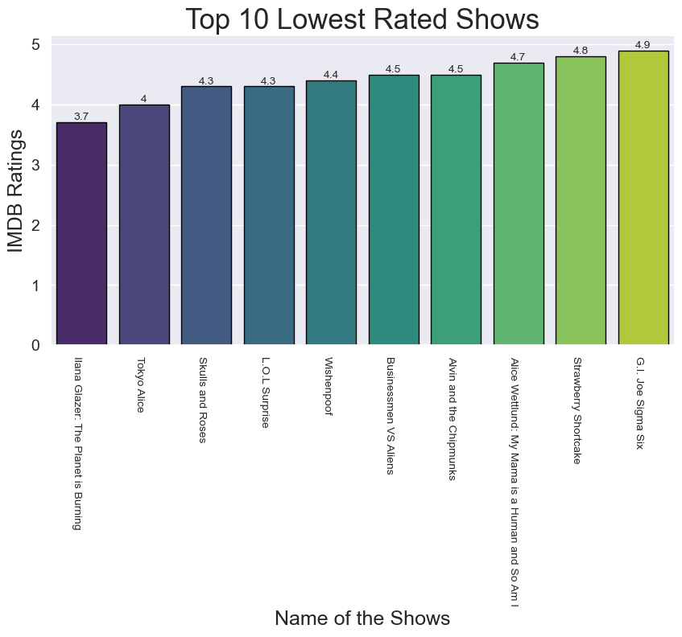

```python
plt.figure(figsize=(10,5))
plt.title('Top 10 Lowest Rated Shows',fontsize=25)
plt.xlabel('',fontsize=18)
plt.ylabel('',fontsize=18)
plt.xticks(rotation=270,ha='right',fontsize=10)
plt.yticks(fontsize=14)
Graph=sns.barplot(data=Lowest,y='IMDb rating',x='Name of the show',palette='viridis',
                  edgecolor='black')
Graph.set(xlabel='Name of the Shows',ylabel='IMDB Ratings')
Graph.bar_label(Graph.containers[0],fontsize=10)
plt.show()
```

8)(i) To Get the List of Top 10 Highly Rated English Shows.

```python
English_Top_10=Data[Data['Language']=='English'].sort_values(by='IMDb rating',ascending=False).head(10)
English_Top_10
```

|  | Name of the show | Year of release | No of seasons available | Language | Genre | IMDb rating | Age of viewers |
| --- | --- | --- | --- | --- | --- | --- | --- |
| 20 | The Test: A New Era for Australia's Team | 2020 | 1 | English | Documentary | 9.0 | 16+ |
| 281 | Seinfeld | 1990 | 9 | English | Comedy | 8.8 | 13+ |
| 4 | Fleabag | 2016 | 2 | English | Comedy | 8.7 | 18+ |
| 51 | This is Us | 2017 | 3 | English | Drama | 8.7 | 16+ |
| 49 | Downtown Abbey | 2010 | 6 | English | Drama | 8.7 | 7+ |
| 2 | The Marvelous Mrs. Maisel | 2017 | 3 | English | Drama, Comedy | 8.7 | 16+ |
| 340 | The Grand Tour | 2017 | 4 | English | Sports | 8.7 | 16+ |
| 12 | The Boys | 2019 | 1 | English | Action, Comedy | 8.7 | 18+ |
| 105 | Mad Men | 2007 | 7 | English | Drama | 8.6 | 16+ |
| 436 | Tumble Leaf | 2014 | 6 | English | Kids | 8.6 | All |

8)(ii) To Plot the Bar Graph.

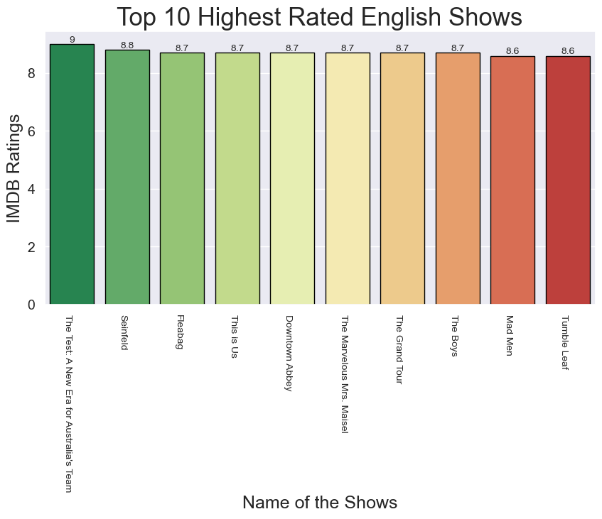

```python
plt.figure(figsize=(10,5))
plt.title('Top 10 Highest Rated English Shows',fontsize=25)
plt.xlabel('',fontsize=18)
plt.ylabel('',fontsize=18)
plt.xticks(rotation=270,ha='right',fontsize=10)
plt.yticks(fontsize=14)
Graph=sns.barplot(data=English_Top_10,y='IMDb rating',x='Name of the show',palette='RdYlGn_r',
                  edgecolor='black')
Graph.set(xlabel='Name of the Shows',ylabel='IMDB Ratings')
Graph.bar_label(Graph.containers[0],fontsize=10)
plt.show()
```

9)(i) To Get the List of Top 10 Highly Rated Hindi Shows.

```python
Hindi_Top_10=Data[Data['Language']=='Hindi'].sort_values(by='IMDb rating',ascending=False).head(10)
Hindi_Top_10
```

|  | Name of the show | Year of release | No of seasons available | Language | Genre | IMDb rating | Age of viewers |
| --- | --- | --- | --- | --- | --- | --- | --- |
| 37 | Hostel Daze | 2019 | 1 | Hindi | Drama, Comedy | 8.7 | 16+ |
| 8 | The Family Man | 2019 | 1 | Hindi | Drama, Action | 8.6 | 18+ |
| 7 | Mirzapur | 2018 | 1 | Hindi | Drama | 8.5 | 18+ |
| 16 | Breathe | 2018 | 1 | Hindi | Drama, Suspense | 8.4 | 16+ |
| 5 | Made in Heaven | 2019 | 1 | Hindi | Drama | 8.3 | 18+ |
| 299 | Best of AIB | 2014 | 1 | Hindi | Comedy | 8.2 | 16+ |
| 11 | Inside Edge | 2017 | 2 | Hindi | Sports, Drama | 8.0 | 18+ |
| 17 | The Forgotten Army- Azaadi ke Liye | 2020 | 1 | Hindi | Drama, Action | 8.0 | 18+ |
| 83 | Bang Baaja Baaraat | 2015 | 1 | Hindi | Drama | 8.0 | 18+ |
| 0 | Pataal Lok | 2020 | 1 | Hindi | Drama | 7.5 | 18+ |

9)(ii) To Plot the Bar Graph.

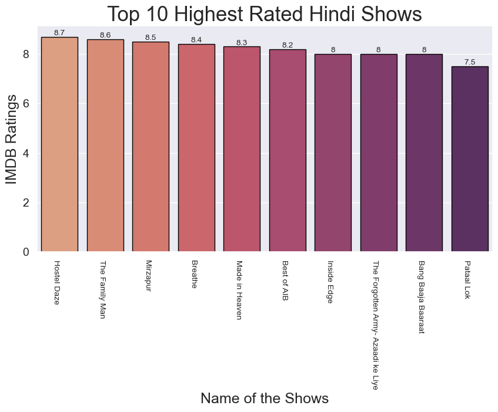

```python
plt.figure(figsize=(10,5))
plt.title('Top 10 Highest Rated Hindi Shows',fontsize=25)
plt.xlabel('',fontsize=18)
plt.ylabel('',fontsize=18)
plt.xticks(rotation=270,ha='right',fontsize=10)
plt.yticks(fontsize=14)
Graph=sns.barplot(data=Hindi_Top_10,y='IMDb rating',x='Name of the show',palette='flare',
                  edgecolor='black')
Graph.set(xlabel='Name of the Shows',ylabel='IMDB Ratings')
Graph.bar_label(Graph.containers[0],fontsize=10)
plt.show()
```

10. To Get the List of Top Highly Rated Shows of 2018.

```python
Data[Data['Year of release']==2018].sort_values(by='IMDb rating',ascending=False).head(10)
```

|  | Name of the show | Year of release | No of seasons available | Language | Genre | IMDb rating | Age of viewers |
| --- | --- | --- | --- | --- | --- | --- | --- |
| 7 | Mirzapur | 2018 | 1 | Hindi | Drama | 8.5 | 18+ |
| 16 | Breathe | 2018 | 1 | Hindi | Drama, Suspense | 8.4 | 16+ |
| 216 | An Unknown Enemy | 2018 | 1 | Spanish | Drama | 8.1 | 18+ |
| 18 | Tom Clancy's Jack Ryan | 2018 | 2 | English | Drama, Action, Suspense | 8.1 | 16+ |
| 147 | Tokyo Girl | 2018 | 1 | Japanese | Drama, Comedy | 8.1 | 13+ |
| 374 | Hitoshi Matsumoto Presents Documental | 2018 | 3 | Japanese | Comedy | 8.0 | 18+ |
| 235 | Amazon Riders | 2018 | 2 | Japanese | Action | 7.9 | 13+ |
| 157 | Fukuyadou Honpo-Kyoto Love Story | 2018 | 1 | Japanese | Drama, Romance | 7.7 | 13+ |
| 439 | Pete The Cat | 2018 | 5 | English | Kids | 7.6 | All |
| 407 | Kung Fu Panda: The Paws of Destiny | 2018 | 2 | English | Kids | 7.6 | All |

11. To Get the List of Top Highly Rated Shows of 2019.

```python
Data[Data['Year of release']==2019].sort_values(by='IMDb rating',ascending=False).head(10)
```

|  | Name of the show | Year of release | No of seasons available | Language | Genre | IMDb rating | Age of viewers |
| --- | --- | --- | --- | --- | --- | --- | --- |
| 12 | The Boys | 2019 | 1 | English | Action, Comedy | 8.7 | 18+ |
| 37 | Hostel Daze | 2019 | 1 | Hindi | Drama, Comedy | 8.7 | 16+ |
| 8 | The Family Man | 2019 | 1 | Hindi | Drama, Action | 8.6 | 18+ |
| 5 | Made in Heaven | 2019 | 1 | Hindi | Drama | 8.3 | 18+ |
| 23 | Undone | 2019 | 1 | English | Animation, Drama | 8.2 | 16+ |
| 9 | Modern Love | 2019 | 1 | English | Drama, Romance, Comedy | 8.0 | 16+ |
| 54 | Carnival Row | 2019 | 1 | English | Drama, Fantasy | 7.9 | 16+ |
| 334 | Jim Gaffigan: Quality Time | 2019 | 1 | English | Comedy | 7.6 | 13+ |
| 13 | Hanna | 2019 | 2 | English | Drama, Action | 7.5 | 16+ |
| 366 | Flo and Joan: Alive on Stage | 2019 | 1 | English | Arts, Entertainment, Culture | 7.4 | 16+ |

12. To Get the List of Top Highly Rated Shows of 2020.

```python
Data[Data['Year of release']==2020].sort_values(by='IMDb rating',ascending=False).head(10)
```

|  | Name of the show | Year of release | No of seasons available | Language | Genre | IMDb rating | Age of viewers |
| --- | --- | --- | --- | --- | --- | --- | --- |
| 20 | The Test: A New Era for Australia's Team | 2020 | 1 | English | Documentary | 9.0 | 16+ |
| 452 | Jessy and Nessy | 2020 | 1 | English | Kids | 8.3 | All |
| 1 | Upload | 2020 | 1 | English | Sci-fi comedy | 8.1 | 16+ |
| 17 | The Forgotten Army- Azaadi ke Liye | 2020 | 1 | Hindi | Drama, Action | 8.0 | 18+ |
| 73 | Star Trek: Picard | 2020 | 1 | English | Sci-fi | 7.6 | 18+ |
| 0 | Pataal Lok | 2020 | 1 | Hindi | Drama | 7.5 | 18+ |
| 19 | Tales from the Loop | 2020 | 1 | English | Sci-fi | 7.5 | 18+ |
| 493 | Learning with Anima Cars | 2020 | 1 | English | Kids | 7.4 | All |
| 492 | Shark Academy: Nursery Rhymes for Kids | 2020 | 1 | English | Kids | 7.4 | All |
| 339 | Zoe Coombs Marr: Bossy Bottom | 2020 | 1 | English | Comedy | 7.4 | 18+ |

13. To Get the List of Latest Released Shows.